# 2 Extraktion thematischer Statements

Nachdem im vorangegangenen Kapitel der Korpusaufbau beschrieben wurde, der von der Idee eines Samplings der Grundgesamtheit der literarischen Romanproduktion der Zeit 1751-1800 hinsichtlich der Parameter Erstpublikationsdatum, Gender und Erzählform getragen wurde, sollen in diesem Kapitel nun die erste Analysemethode und deren Ergebnisse dargelegt werden: die Extraktion thematischer Statements aus den Volltexten mithilfe von Topic Modeling und die Extraktion thematischer Aussagen aus den bibliographischen Metadaten. Topic Modeling ist ein in den Digital Humanities beliebtes Verfahren der unüberwachten Extraktion semantischer Cluster in Textsammlungen. Im vorliegenden Kapitel wird zunächst die Topic Modeling Pipeline beschrieben, die Preprocessing, Modellierung und Postprocessing umfasst. Zudem wird die Extraktion thematischer Statement aus bibliographischen Metadaten umrissen. Im Zuge der Vergleichbarkeit der Statements aus beiden Quellen wurde ein kontrolliertes Vokabular erstellt, das ebenfalls in diesem Kapitel beschrieben wird. Anhand von Fallbeispielen mit SPARQL-Abfragen werden die Ergebnisse aus Topic Modeling und aus der Extraktion thematischer Statements aus bibliographischen Metadaten betrachtet: Wie hat sich das Themenkonzept Glück im Zeitverlauf verändert? Was sind die häufigsten Themen von Werken mit anonymer Autorschaft? Mit welchen Handlungsorten ist das Themenkonzept “sentimentalisme” verknüpft? Gibt es thematische Unterschiede zwischen Autorinnen und Autoren? Welche Themen-Cluster hat der Topic Modeling Algorithmus im Gegensatz zur menschlichen Lektüre identifiziert?

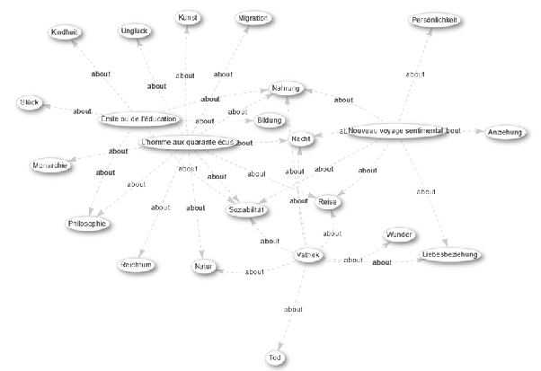

**Abb. 3.1** MiMoText-Graph: Ausschnitt aus den „about“-Statements [Wikibase #defaultView:Graph].

Insbesondere im Zusammenspiel und Vergleich zwischen thematischen Aussagen der in den bibliographischen Metadaten [(Martin / Mylne / Frautschi 1977; Lüschow 2019)](https://www.zotero.org/google-docs/?4b66LI) enthaltenen thematischen Keywords und einer Extraktion thematischer Strukturen in den Volltexten mithilfe von Machine Learning sehe ich ein vielversprechendes Potential für eine datenbasierte Literaturgeschichte.

Doch wie lassen sich große Korpora hinsichtlich ihrer literarischen Themen explorativ digital erforschen? Als Verfahren fiel die Wahl auf die unüberwachte Methode Topic Modeling, die in der hier vorgestellten Implementation auf der statistischen Methode *Latent Dirichlet Allocation* basiert [(Blei / Ng / Jordan 2003)](https://www.zotero.org/google-docs/?1VIPBG).

While more and more texts are available online, we simply do not have the human power to read and study them […]. To this end, machine learning researchers have developed *probabilistic topic modeling*, a suite of algorithms that aim to discover and annotate large archives of documents with thematic information. [(Blei 2012: 77)](https://www.zotero.org/google-docs/?N5U3aL).

Wie [(Du 2019)](https://www.zotero.org/google-docs/?24S4Di) analysiert, etabliert sich die Methode Topic Modeling zunehmend in den Digital Humanities und findet in den Geisteswissenschaften vor allem in Geschichtswissenschaften und Literaturwissenschaften Anwendung. Wie [(Schröter / Du 2022)](https://www.zotero.org/google-docs/?fOxUUn) ausführen, lässt sich zwar eine vereinfachte Gleichsetzung von Topics und Aboutness[^2] literarischer Werke nicht begründen, jedoch lässt sich die Methode Topic Modeling als “approximation to aboutness under certain conditions” [(Schröter / Du 2022: 3)](https://www.zotero.org/google-docs/?1IOP8S) bestimmen.[^3] Bereits [(Binder / Jennings 2014)](https://www.zotero.org/google-docs/?Nlq5WF) haben herausgearbeitet, dass sich eine Kontinuität zwischen Themen-Indizes früherer Jahrhunderte und Topic Modeling Ergebnissen herstellen lässt.

Das Verfahren Topic Modeling kann grundsätzlich zur Analyse verschiedener Arten von Daten eingesetzt werden: Neben Bildern, genetischen Daten oder Zeitungsarchiven [(Blei 2011)](https://www.zotero.org/google-docs/?EjMGwA) lässt sich der Algorithmus mit entsprechenden Parametereinstellungen auch auf literarische Texte anwenden, wie zahlreiche Studien in den Digital Humanities zeigen konnten [(Underwood 2012; Rhody 2013; Jockers 2014; Schöch 2017)](https://www.zotero.org/google-docs/?WZsCrA). Die Methode, die von einer möglichst großen Datenmenge profitiert, berücksichtigt die Kookkurrenz von Wörtern und generiert auf dieser Grundlage Gruppen von semantisch verwandten Wörtern, die als Topics bezeichnet werden. Ähnlich wie bei der Principal Component Analysis (PCA) handelt es sich bei Topic Modeling um eine Dimensionalitätsreduktion, die jedoch im Vergleich zu Methoden wie PCA interpretierbarere Ergebnisse liefert, was möglicherweise ihren beliebten Einsatz in den Digital Humanities oder Sozialwissenschaften begründet.

Man kann bei Topic Modeling wie [(Wiedemann / Fedtke 2021)](https://www.zotero.org/google-docs/?ca3Ygf) von einem “Saussurian Turn” sprechen, einer Trennung zwischen *signifiant* und *signifié* (s. Abb. 3.2): “The latent semantic variables of topic models are based on a separation of the meaning representation of words from their linguistic surface form.” [(Wiedemann 2022: 286–287)](https://www.zotero.org/google-docs/?1FauaW).[^4]

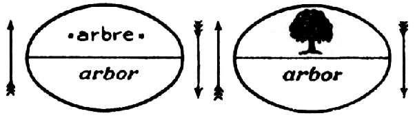

**Abb. 3.2** Ferdinand de Saussure: *Cours de linguistique générale (1916).* Auch bei der Methode Topic Modeling wird zwischen *signifié* und *signifiant* unterschieden, Bildquelle: Wikicommons.

Jedes Topic setzt sich aus Topic-Wörtern zusammen, die je nach Gewichtung gerankt ausgegeben werden können (s. Appendix A, Topics mit Top Topic Words). Eine Saussuresche Betrachtung bedeutet, dass ein Top Topic-Wort, welches zwei sehr unterschiedliche Bedeutungen hat, gegebenenfalls in zwei unterschiedlichen Topic Clustern auftauchen kann, gemäß der unterschiedlichen Kookkurrenzen. Das Topic-Wort ‘lumière’, das sowohl das physikalische Licht als auch Erkenntnis/Erleuchtung bedeuten kann, könnte so in zwei unterschiedlichen Topics gemäß seiner Kookkurrenzen vorkommen. Oder auch in den Worten von John. R Firth: »You shall know a word by the company it keeps.« [(Firth 1957: 11)](https://www.zotero.org/google-docs/?6IfrJq).

Beispiele für den erfolgreichen Einsatz der Methode Topic Modeling auf literarischen Texten sind Christof Schöchs Studie zu Topic Modeling auf französischen Dramen-Texten der Klassik und Aufklärung, die Topic Modeling Ergebnisse und Gattungen korreliert, oder auch Katherine Bodes Topic Modeling Arbeiten auf fiktionalen Texten in australischen Zeitungen, in denen sie als zusätzlichen Parameter Gender analysiert (Bode 2018: 156-198; Schöch 2017).

Im Falle des hier untersuchten Korpus ist zu beachten, dass französische Texte aus dem 18. Jahrhundert Charakteristika haben, die in der Topic Modeling Pipeline durch entsprechende Preprocessing-Schritte berücksichtigt werden müssen. Forschungsprojekte wie ARTFL (American and French Research on the Treasury of the French Language) haben Topic Modeling bereits auf Texten des 18. Jahrhundert erprobt und die Artikel der *Encyclopédie ou Dictionnaire raisonné des sciences, des arts et des métiers* mithilfe von Topic Modeling analysiert. Dabei unterstreichen sie vor allem die Möglichkeit, über Topic Modeling Diskurse abzubilden [(Roe / Gladstone / Morrissey 2016)](https://www.zotero.org/google-docs/?vzti7Y). Elizabeth Andrews Bond und Robert M. Bond haben 2020 eine Studie zu Topic Modeling in vorrevolutionären französischen Presseartikeln vorgelegt [(Bond / Bond 2020)](https://www.zotero.org/google-docs/?bxYeLA), wobei sie ihre Analyse mit dem stm-Package von R [(Roberts et al. 2020)](https://www.zotero.org/google-docs/?630zS4) durchgeführt haben.

Im Kontext der hier vorliegenden Arbeit wurde Topic Modeling mit MALLET in Python auf das entstandene Romankorpus „Collection de romans français du dix-huitième siècle (1751-1800)” in der Version 0.1.0 (kurz: roman18) angewendet. Die Topic Modeling-Pipeline basiert auf [(Schöch 2020)](https://www.zotero.org/google-docs/?0XjOWr) und wurde an die Anforderungen des Projektes angepasst [(Klee / Röttgermann 2020)](https://www.zotero.org/google-docs/?r1rjjV).

# 3 3.1 Datengrundlage

Datengrundlage der im folgenden besprochenen Topic Modeling Analyse ist das Korpus „Collection de romans français du dix-huitième siècle (1751-1800)” in der Version 0.1.0 mit 80 französischen Romanen 1751-1800 [(Röttgermann 2020)](https://www.zotero.org/google-docs/?PJucQ2), welches ausführlich in Kapitel 2 (Korpusaufbau) beschrieben wird.

3.1.2 Thematische Aussagen in der Bibliographie

In der *Bibliographie du genre romanesque français* ([Martin / Mylne / Frautschi 1977](https://www.zotero.org/google-docs/?3pnqET)) sind zu jedem zwischen 1751 und 1800 erschienenen französischen Roman neben einem eindeutigen numerischen Identifier und weiteren Metadaten auch ein Keyword-Feld mit thematischen Informationen pro Werk enthalten (Abb. 3.6).

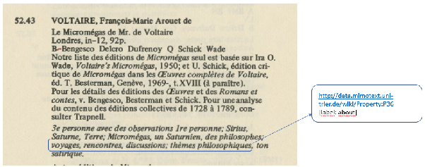

**Abb. 3.6** Angaben zu Themen in den Keywords (hier kursiv) der *Bibliographie du genre romanesque français* [(Martin / Mylne / Frautschi 1977: 16)](https://www.zotero.org/google-docs/?ioQFxB).

Die Bibliographie wurde in mehreren Arbeitsschritten aufwendig erschlossen. Ausgewählt wurden mithilfe von TXM [(Heiden 2010)](https://www.zotero.org/google-docs/?buSwyK) zum einen Strings mit mindestens acht Vorkommen in der Bibliographie und darüber hinaus solche mit einer besonderen Relevanz in den anderen Informationsquellen und für die literaturgeschichtliche Domäne insgesamt.

Die statistische Übersicht in Abb. 3.7 der thematischen Werte im Korpus der bibliographischen Einträge 1751-1800 liefert einen ersten Eindruck der darin enthaltenen Kategorien.

### 3.0.1 **Abb. 3.7** Kategorien der Themen und Handlungselemente („thèmes et intrigues” ) des französischen Romans 1751-1800 im Zeitverlauf, Daten: [(Martin / Mylne / Frautschi 1977: xlviii)](https://www.zotero.org/google-docs/?l4Wt1P).

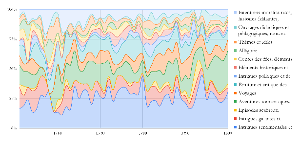

In der Analyse der Themenkategorien im zeitlichen Verlauf (siehe Abbildung 3.7) lässt sich feststellen, dass religiöse und moralisierende Aspekte im französischen Roman der zweiten Hälfte des 18. Jahrhunderts eine rückläufige Tendenz aufweisen. Hingegen zeigen die Themen Erziehung (“éducation”) und Reise (“voyage”) eine prozentuale Zunahme in den Dekaden ab 1780.

Basierend auf den im Jahr 1977 veröffentlichten Themenwerten für den französischen Roman in der Zeitspanne von 1751 bis 1800, die in den bibliographischen Metadaten enthalten sind, stellt sich nun die Frage, welche Themen durch den Topic Modeling Algorithmus mit MALLET (McCallum 2002) in den Volltexten [(Röttgermann et al. 2020)](https://www.zotero.org/google-docs/?broken=1y7ggY) generiert werden.

# 4 3.2 Topic Modeling Workflow

Der hier vorgestellte Topic Modeling Workflow (Abb. 3.8) beinhaltet verschiedene Vorverarbeitungsschritte, wie das Abschneiden der Texte in Abschnitte von 1000 Wörtern (Splitting) und eine Lemmatisierung, das heißt eine Rückführung der Wörter auf ihre lemmatisierte Form. Bei der Lemmatisierung wird beispielsweise aus der konjugierten Verbform *ai* (“habe”) das Lemma *avoir* (“haben”). Zudem wurden die Wörter automatisiert hinsichtlich ihrer Wortform ausgezeichnet (POS-Tagging), sodass nach bestimmten Wortformen, nämlich Substantiven, Adjektiven, Adverbien und Verben gefiltert werden konnte. Die Schritte dienen — unter der Berücksichtigung von Spezifika literarischer Prosatexte — dazu, die Texte auf den Prozess des Topic Modelings vorzubereiten.

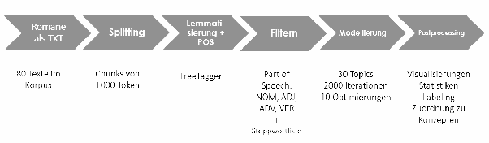

**Abb. 3.8** Topic Modeling-Pipeline

# 5 3.2.1 Input

Das Input-Format der Topic Modeling Pipeline ist teilmodernisierter Plaintext. Im Zuge der Extraktion des Plaintexts aus den XML/TEI-Dokumenten wird der Text mithilfe eines Python-Skriptes modernisiert und normalisiert.

In französischen Texten des 18. Jahrhunderts sind häufige Phänomene im Schriftbild das Schaft-S, welches im Skript mit einem modernen S ersetzt wurde. Des Weiteren treten historische Wort- und Flexionsformen auf, die unter Nutzung einer Modernisierungsliste[^5] durch Suche und Ersetzen im extrahierten Plaintext ersetzt wurden. Für die Liste wurden zuvor mit einem Spellcheck und der Pythonbibliothek enchant (Kelly 2011) die im Korpus vorkommenden historischen Wortformen ermittelt.

Das Abschneiden der langen Romantexte in kürzere, einheitliche lange Abschnitte von 1000 Wörtern ist vonnöten, da der Topic Modeling Algorithmus Wörter in ihrem Kontext betrachtet und dieser demnach nicht zu groß ausfallen sollte.[^6] Würde man als Kontext einen kompletten Romantext verwenden, wären ungenaue Ergebnisse zu erwarten.[^7] Zudem hilft der Prozess des Chunkings das Autorsignal zu dämpfen [(Erlin 2014: 61)](https://www.zotero.org/google-docs/?6Rogx3).

Was ist bei der Wahl der Chunk-Größe zu beachten? Wie Stefano Sbalchiero und Maciej Eder in ihren Testreihen zu Topic Modeling gezeigt haben, hängen Chunk-Länge und optimale Anzahl an Topics (für ein Korpus englischer Romane) zusammen. Sie testen dies für Chunks von 500, 1000, 2000, 3000, 4000, 5000, 6000, 7000, 8000, 9000, 10,000, 15,000, 20,000 und 50,000 Token und können bei einer Korpusgröße von 100 Romanen bei Textchunks von 1000 Token eine ideale Anzahl von Topics zwischen 20 und 40 ausmachen [(Sbalchiero / Eder 2020: 8)](https://www.zotero.org/google-docs/?tSfmvM).

Bei der Wahl der Chunk-Länge und der Anzahl der Topics sollte demnach bedacht werden, dass diese beiden numerischen Größen wechselseitig in Abhängigkeit sind [(Sbalchiero / Eder 2020)](https://www.zotero.org/google-docs/?NsovbI). Ausgehend von einer Chunk-Länge von 1000 Token wurden im hier vorliegenden Topic Modeling Durchlauf daher auch in mehreren Testläufen mit der Anzahl der idealen Topicanzahl experimentiert: 25, 30, 35 oder 40 Topics. Die Anzahl der Topics wurde auf 30 festgelegt. Eine höhere Anzahl zeigte viele semantisch überlappende Topics.

Den Textdateien beigefügt wird eine Metadatentabelle[^8], die später im Postprocessing bei der statistischen Auswertung und Visualisierung der Topic Modeling-Ergebnisse verwendet wird. Sie enthält Informationen zu den Kategorien Gender, Publikationsjahr oder Erzählform.

## 5.1 3.2.2 *Preprocessing: POS-Tagging und Filtern*

Vor der Modellbildung werden die eingespielten Textdateien einer üblichen Vorverarbeitung unterzogen. Im ersten Schritt erfolgt die Lemmatisierung der Texte mithilfe des Tools TreeTagger (Schmid 1994). Mit dem Ziel, semantisch gehaltvolle Topics zu generieren, werden die Texte vorab nach Wortarten gefiltert. In die Modellierung fließen ausschließlich Lemmata der Wortarten Substantiv, Adjektiv, Adverb und Verb ein.

Zusätzlich werden mit zwei Stoppwortlisten bestimmte Wortarten herausgefiltert: Einerseits Hilfsverben und andererseits Figurennamen, die typisch für die Textsorte Roman sind und beim POS-Tagging nicht als Eigennamen erkannt wurden. Beide Kategorien treten in den Texten häufig auf, tragen jedoch wenig zur Identifikation thematischer Muster bei.

## 5.2 3.2.3 *Modellierung*

Grundlage der Modellierung bildet das *Bag-of-Words-Modell,* das davon ausgeht, dass die genaue Abfolge der Wörter für das Auffinden thematischer Strukturen innerhalb der Dokumente ignoriert werden kann. Des Weiteren wird angenommen, dass jedes Dokument eine Mischung aus (latenten) Topics ist und jedes Topic eine Mischung aus Wörtern (Abb. 3.9).

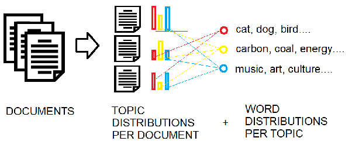

**Abb. 3.9** Topic Modeling, Bildquelle: Wikicommons, Anna Ristilä, 2022-03-07.

Für die konkrete Durchführung der Modellierung wurde das Tool MALLET genutzt [(McCallum 2002)](https://www.zotero.org/google-docs/?MccIFl).[^9] Über den Gensim-Wrapper LdaMallet[^10] konnte MALLET in die Python-Pipeline integriert werden. Ein Modell mit 30 Topics erwies sich für das Korpus von etwa 80 Texten als optimal, da es ein ausgewogenes Spektrum ohne übermäßige semantische Überschneidungen oder generische Topics bietet. Für den Trainingsprozess wurden 2000 Iterationen und 10 Optimierungen verwendet, da diese Parameter eine gute Balance zwischen Laufzeit und Modellqualität ermöglichten.  
Hinsichtlich der Modellierung ist anzumerken, dass die genauen Ergebnisse nur eingeschränkt reproduzierbar sind, da bei jedem erneuten Topic Modeling Durchgang stochastische Inferenzverfahren durch ihre iterativen Schätzverfahren auch leichte Verschiebungen in den Ergebnissen mit sich bringen können. Es ist bei erneuten Durchläufen erwartbar, dass sich 50-80% der Topics reproduzieren lassen, wie Studien zeigen (Maier et al. 2021).

## 5.3 3.2.4 *Postprocessing und Visualisierung*

Das Postprocessing umfasst die Erstellung von Statistiken und Visualisierungen, die sowohl der Analyse thematischer Aussagen dienen als auch den Nutzer:innen des Wissensnetzwerks bereitgestellt werden. Das berechnete Topic Model besteht aus einer festgelegten Anzahl von Topics, die aus Wahrscheinlichkeitsverteilungen der Wörter und ihrer Zuordnung zu den Textdokumenten bestehen. Daraus werden CSV-Dateien generiert, und basierend auf den wahrscheinlichsten Wörtern wird jedem Topic ein Label zugewiesen.[^11] Aus der Verteilung der Top-Topics pro Werk werden thematische Aussagen abgeleitet.

Dabei ist anzumerken, dass im Grunde jedes Topic in jedem Werk vorhanden ist. Es tritt jedoch erst ab einer bestimmten Wahrscheinlichkeit signifikant in Erscheinung, ab der vereinfacht davon gesprochen werden kann, dass es in einem Werk vorkommt. Dabei werden für jeden Roman die fünf wahrscheinlichsten Topics berechnet, bei vorheriger Aussortierung aller Topics, die in weniger als 10 % und in mehr als 80% der Korpuswerke enthalten sind. Die soll sicherstellen, dass einerseits sehr seltene, oft werkspezifische Topics als auch sehr häufige, meist generische Topics ausgeschlossen werden, da sie für den Vergleich von Themen zwischen den Werken keinen Mehrwert bieten.[^12]

3.2.5 *Labeling mithilfe eines kontrollierten Vokabulars*

Ein kontrolliertes Vokabular dient dazu, Begriffe und Konzepte einheitlich und standardisiert zu benennen, um Daten aus verschiedenen Quellen und Sprachen zu integrieren und zu vereinheitlichen. Im hier vorgestellten Setting wurden die aus Topic Modeling gewonnen Themenaussagen, thematische Informationen aus Sekundärliteratur und aus bibliographischen Metadaten in einem kontrollierten Themenvokabular erfasst. Als Grundlage der Einträge wurde eine weitere Quelle herangezogen, das Inventar des *Dictionnaire européen des Lumières* [(Blay et al. 1997, Abb. 3.12)](https://www.zotero.org/google-docs/?XBmRh4), das unter Mitwirkung von 200 Autor:innen entstanden ist und typische Themenkonzepte der französischen Aufklärung enthält.

### 5.3.2

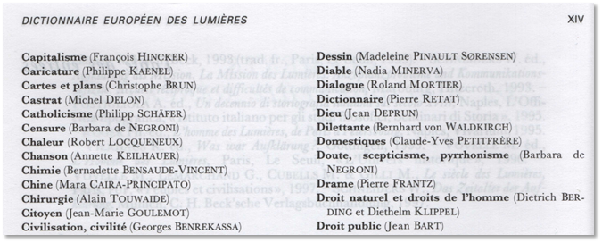

**Abb. 3.12** Ausschnitt aus dem *Dictionnaire européen des Lumières* [(Blay et al. 1997)](https://www.zotero.org/google-docs/?XBmRh4), das als Grundlage eines kontrollierten Themenvokabulars dient.

Das Inventar des Dictionnaire européen des Lumières enthält jedoch auch Begriffe, die entweder zu spezifisch (z.B. „cristallographie“) oder zu generisch (z.B. „fonction“) sind, um literarische Themen zu beschreiben, weshalb diese nicht ins Vokabular aufgenommen wurden. Ergänzt wurde das Vokabular um fehlende Konzepte zur Kennzeichnung der Topics, thematische Schlagworte aus der Bibliographie (vgl. Martin / Mylne / Frautschi 1977) sowie der wiederkehrenden Themenkonzepte aus der Sekundärliteratur, die noch nicht abgedeckt waren. Das Vokabular ist nun konsolidiert, bleibt aber erweiterbar, etwa bei einer erneuten Topic Modeling Analyse mit einem größeren Textkorpus.

Um die multilinguale Vergleichbarkeit zwischen französischsprachigen Primärtexten und deutschsprachiger Sekundärliteratur zu sichern und die Anschlussfähigkeit sowie Interoperabilität mit anderen Datenbeständen zu gewährleisten, wurden die Themenkonzepte auf einen Normdatensatz (Wikidata) gemappt. Dadurch wurde das kontrollierte Vokabular um Label in mehreren Sprachen erweitert (s. Abb. 3.13).[^16]

### 5.3.3

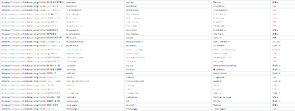

**Abb. 3.13** Ausschnitt aus dem kontrollierten Vokabular zur Extraktion thematischer Konzepte, das aus Einträgen des *Dictionnaire européen des Lumières* [(Blay et al. 1997)](https://www.zotero.org/google-docs/?HeYHis), aus den thematischen Schlagworten der *Bibliographie du genre romanesque français 1751-1800* [(](https://www.zotero.org/google-docs/?broken=lqz8uM)[Martin / Mylne / Frautschi 1977](https://www.zotero.org/google-docs/?gg8WgX)[)](https://www.zotero.org/google-docs/?broken=lqz8uM) und aus der im Projekt ausgewerteten Sekundärliteratur hervorgegangen ist [(Klee / Hinzmann 2021)](https://www.zotero.org/google-docs/?k8v0ng).

Das derzeit 368 Einträge umfassende Vokabular der Themenbegriffe in Deutsch, Französisch und Englisch bildet die Konzept-Items für die Objektposition aller thematischen Aussagen. Zur Erstellung der Topic Modeling-Aussagen wird daher jedem Topic ein Label aus diesem Inventar manuell zugewiesen. Da einige Topics sehr generisch sind und nur eine geringe semantische Kohärenz aufweisen, ist es nicht immer möglich, ein präzises Label zu vergeben. In solchen Fällen werden die ersten drei Wörter des Topics als Label verwendet, wie beispielsweise „[point voir jour]”. Generische Topics entstehen, weil häufig vorkommende Wörter, die in vielen Texten des Korpus auftreten, statistisch stark miteinander verknüpft werden, unabhängig von ihrem Kontext. Dadurch fehlt diesen Topics eine klare semantische Trennschärfe.

Der Import der Themenstatements in das Wissensnetzwerk erfolgte über einen Bot [(Steffes 2021)](https://www.zotero.org/google-docs/?5R6hJK) und TSV-Listen, die einen spezifischen Header enthalten (Abb. 3.14).[^17] In der Liste wurden eindeutige numerische Identifier pro Werk importiert, die Themenwerte laut Bibliographie als String (Spalte: text) und der gemappte Themenwert (Spalte: Keyword). Die Property der Themenstatements, die die Themenwerte als String enthält ist P30, die Property der Themenwerte als kontrolliertes Vokabular ist P36.

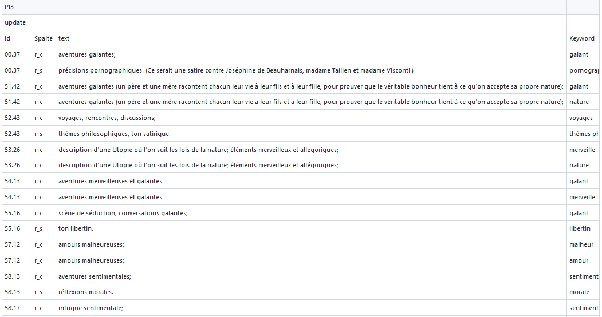

**Abb. 3.14** TSV-Liste für Wikibase-Bot [(Steffes 2021)](https://www.zotero.org/google-docs/?GCmm0P).

Die Themenwerte als String (P30) lassen sich später ebenfalls per SPARQL abfragen, jedoch bietet das kontrollierte Vokabular der Themen eine bessere Übersicht, Einheitlichkeit und dadurch Vergleichbarkeit. Außerdem sind die Entitäten der Themen eigene Q-items, die eine Verknüpfung zu Wikidata enthalten.

# 6 3.2.6 Ergebnis der Themenextraktion aus zwei Quellen

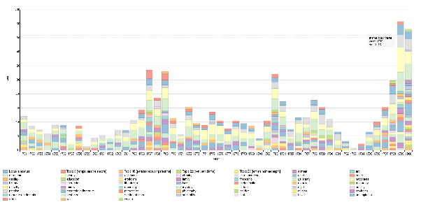

**Abb. 3.15** Themenwerte aus beiden Quellen pro Jahr, https://tinyurl.com/256e7jlk.

Folgt man dem [Link](https://tinyurl.com/2b6tulbg) können auch über Klick auf die Themenwerte die diachrone Entwicklung für einzelne Themen oder für eine Auswahl an Themen betrachtet werden, so z.B. hier für die Werte sentiment, sentimentalism, melancholia, love, eroticism, libertinism, passion im Zeitverlauf (Abb. 3.16).

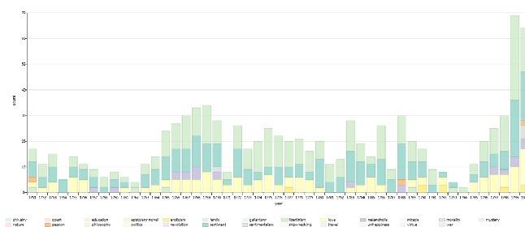

**Abb. 3.16** Ausgewählte Themenwerte pro Jahr (sentiment, sentimentalism, melancholia, love, eroticism, libertinism, passion).

Wir können in der zeitlichen Anordnung der Themenwerte einige Muster erkennen, beispielsweise nimmt die prozentuale Anzahl von Werken, die *vertu* thematisieren ab, und die prozentuale Anzahl an Werken, die *sentiment* und *sentimentalisme* thematisieren zu.

Neben einer diachronen Betrachtung der Themenwerte visualisiert in Barcharts sind weitere Auswertungen möglich. In Abb. 3.17 werden alle mit dem Wert *family* gemeinsam vorkommenden Themenwerte im gesamten Graphen in Form eines Chord Diagramms visualisiert.

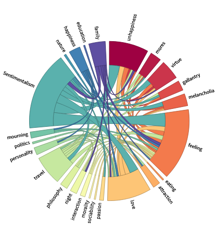

**Abb. 3.17** SPARQL-Abfrage, die zählt, welche Themenwerte im Graphen häufig miteinander vorkommen (Co-Nodes bezogen auf ‘about’ für items mit MiMoText-ID); Endpoint ist Wikidata: https://w.wiki/CoSh, NEU: https://w.wiki/DxCq, Visualisierung ist erzeugt mit https://dataviz.toolforge.org/ als Chord Diagram.

Man erkennt in Abb. 3.17., dass im Graphen das Themenkonzept Familie (“family”) häufig zusammen mit dem Themenkonzept *sentimentalism, feeling*, *unhappiness*, *love*, oder *virtue* auftritt. Wir können für den französischen Roman der zweiten Hälfte des 18. Jahrhunderts eine Kookkurrenz des Themas Familie mit Themen des Sentimental- oder Liebesromans feststellen. Die Liebesbeziehung wird in den Romanen der Zeit häufig in Kombination mit dem Thema Familie verhandelt, was auf die Rolle der Familie im Hinblick auf die Partnerschaft und Partnerwahl im 18. Jahrhundert hinweist. Die zweite Hälfte des 18. Jahrhunderts war von tiefgreifenden sozialen Wandlungsprozessen geprägt – von Forderungen nach individueller Freiheit bis hin zu rechtlichen Reformen in Ehe- und Erbrecht. Vor allem im Vorfeld der Französischen Revolution wurde das traditionelle aristokratische Familienmodell zunehmend hinterfragt, während sich bürgerliche Werte durchsetzten, die auf Liebe als Basis der Ehe setzten. In den philosophischen und politischen Schriften der Zeit wurde den Frauen jedoch oft eine Rolle in Haushalt und Kindererziehung zugedacht und die französische Revolution verstärkte sogar die Tendenz, Frauen aus der politischen Öffentlichkeit auszuschließen (Tricoire 2023, p.205-223). Viele Romane thematisierten den Versuch, Liebe und familiäre Verpflichtungen zu vereinen oder zeigten, wie diese unvereinbar waren. Umbrüche in neuen Vorstellungen von persönlicher Freiheit, elterlicher Autorität und Geschlechterrollen innerhalb von Liebe und Ehe treten in der Kombination der Themen Familie und Liebe auf.  
Eine Heirat, Affäre oder Trennung kann positive oder negative soziale Folgen für die gesamte Familie haben, einen sozialen Aufstieg verheißen oder die Tugendhaftigkeit der gesamten Familie kompromittieren. Ein Beispiel für die Verquickung von Liebesbeziehung und Familie als Themenkookurrenz ist der in Frankreich rege rezipierte Bestseller aus England *Pamela* (1740) von Richardson, der die Folgen dieses Spannungsverhältnisses in emotionalen Briefen zwischen Tochter und Eltern durchdekliniert, aber auch Rousseaus *Julie ou la nouvelle Héloïse* (1761).

# 7 3.3. Anwendungsfälle | SPARQL-Queries

In einer Reihe an skizzierten Anwendungsszenarien soll im Folgenden gezeigt werden, wie sich Forschungsfragen mithilfe der thematischen Statements in die Abfragesprache SPARQL übersetzen lassen und die Ergebnisse in ihrer Musterhaftigkeit Aufschluss über quantitative Entwicklung im französischen Roman des 18. Jahrhunderts bieten. Es lassen sich Fragen wie: “Was sind die häufigsten Themen von Romanen mit anonymer Autorschaft? Was sind die häufigsten Themenkonzepte im Briefroman? Welche Themen wurden per Topic Modeling extrahiert im Vergleich zur Extraktion der Themen aus bibliographischen Metadaten? Wie hat sich das Thema ‘Glück’ im französischen Roman im Zeitverlauf verändert?” beantworten.

# 8 3.3.1 Wie hat sich die Erzählform ‘Briefroman’ entwickelt? Was sind die häufigsten Themenkonzepte im Briefroman?

Eine Entwicklung der Erzählform Briefroman lässt sich im Knowledge Graphen mit folgender Query abfragen (Abb. 3.25).

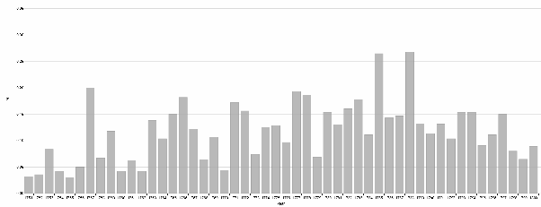

**Abb. 3.25** Wie hat sich die Erzählform Briefroman 1751-1800 verändert? Die SPARQL-Query zeigt den prozentualen Anteil an Romanen mit Property P22 (narrative form) mit Wert “epistolary (narrative form)” (Briefroman). https://tinyurl.com/2ddvz9go.

Im Ergebnis der [Abfrage](https://tinyurl.com/2ddvz9go) sehen wir, dass der prozentuale Höhepunkt an Romanen der Gattung Briefroman 1785 und 1788, also ein Jahr vor der Französischen Revolution, erreicht wird und danach wieder sukzessive abfällt. Das Erscheinungsjahr von *Les Liaisons dangereuses* (1782) situiert sich somit einige Jahre vor der höchsten Blütezeit der Gattung Briefroman im 18. Jahrhundert.  
Was können Gründe für die Beliebtheit des Briefromans im 18. Jahrhundert und für das dann zügig wieder zurückgehende Muster sein? Lynn Hunt zieht dazu folgende Begründung heran: “epistolary novels taught their readers nothing less than a new psychology and in the process laid the foundations for a new social and political order.” [(Hunt 2008: 39)](https://www.zotero.org/google-docs/?cpFq4P). Der Briefroman erleichtert laut Hunt das ‘sich in andere Hineinversetzen’, die Empathie, und legt damit den Grund – so Hunts Argumentation – für eine Anerkennung der Gleichheit der Menschen:  
Novels made the point that all people are fundamentally similar because of their inner feelings, and many novels showcased in particular the desire for autonomy. In this way, reading novels created a sense of equality and empathy through passionate involvement in the narrative. [(Hunt 2008: 39)](https://www.zotero.org/google-docs/?0n93Xf).  
Vivienne Mylne hingegen sieht als Grund für das Erstarken des Briefromans im 18. Jahrhundert Richardsons und Rousseaus sehr erfolgreiche Briefromane, die eine Welle an Nachahmern nach sich zogen: “The increase in the vogue of the letter-novel in France was probably due, for the most part, to the popular success achieved both by Richardson and Rousseau in this form.” [(Mylne 1981: 221)](https://www.zotero.org/google-docs/?mIC7gi). Laut Nicolas Paige hingegen handelt es sich bei der Welle von Briefromanen weder um ein “refinement in technique” [(Paige 2018: 61)](https://www.zotero.org/google-docs/?kAnYdL), noch über eine kulturelle Technik, die auf eine neue politische und soziale Ordnung verweist, sondern um eine Zufälligkeit im Rahmen der verfügbaren Modalitäten und der sie umgebenden Gesellschaft:  
So why this particular artifact at that particular moment? For lots of rea-  
sons and no reason. Asking why this or that form arises in one decade and  
peaks in another is hopeless. Things could easily have been otherwise. Not  
radically otherwise, I’m sure. Choices are limited by dominant values and by  
whatever artifacts are available for modification. [(Paige 2018: 63)](https://www.zotero.org/google-docs/?FyrdSc)

Wie ist die Welle an Briefromanen im 18. Jahrhundert zu bewerten? Um dem näher auf den Grund zu gehen, könnten wir in einer weiteren SPARQL-Query fragen, welche Themen im französischen Briefroman der zweiten Hälfte des 18. Jahrhunderts vorherrschend verhandelt werden.

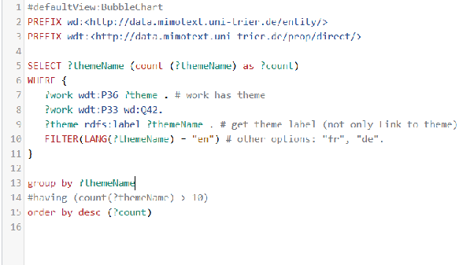

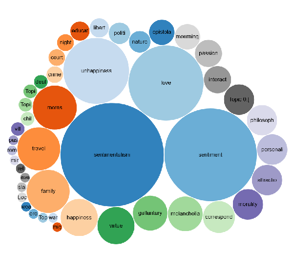

**Abb. 3.26** Was sind die häufigsten Themenwerte des Briefromans? https://tinyurl.com/23x9u774.

Im Ergebnis zeigt sich, dass französische Briefromane der zweiten Hälfte des 18. Jahrhunderts als vorherrschende Themenwerte, hervorgegangen aus bibliographischen Metadaten, Topic Modeling und Themenwerten aus Sekundärliteratur sentimentalism | Empfindsamkeit (116 Romane), sentiment | Gefühl (93 Romane) und love | Liebe (61 Romane), unhappiness | Unglück (47 Romane) und mores | Sitten (21 Romane) aufweisen. Der Briefroman als Medium der Innerlichkeit und der Thematisierung von Gefühlen in einer unmittelbaren Form zeigt sich hier im Ergebnis der entsprechenden Themenwerte, was tendenziell Hunts These plausibel erscheinen lässt.

3.3.2 Was sind die häufigsten Themen von Romanen 1751-1800 mit anonymer Autorschaft?

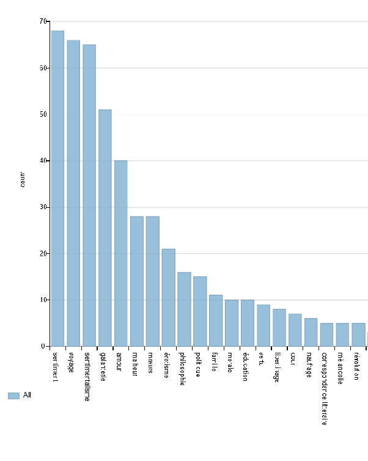

**Abb. 3.30** Top 20 Themen anonymer, französischer Romane 1751-1800, https://tinyurl.com/2fmq7bun.

Es zeigt sich im Ergebnis, dass anonyme Werke im französischen Roman 1751-1800 besonders häufig von Gefühl, Empfindsamkeit, Reise handeln. Auch Erotik, Philosophie oder Politik finden sich in den häufigsten Themen anonymer Werke.[^19] Dass der antiklerikale, erotische oder philosophische französische Roman im 18. Jahrhundert häufig in anonymer Autorschaft erschien, deckt sich mit Forschungsergebnissen aus Sekundärliteratur [(Camus 1985: 237–242)](https://www.zotero.org/google-docs/?lpdg1z).

3.3.3 Wie hat sich das Themenkonzept “Glück” im französischen Roman 1751-1800 in diachroner Betrachtung verändert?

“Le bonheur est une idée neuve en Europe”  
[(Saint-Just 2004: 673)](https://www.zotero.org/google-docs/?CkdX0a)

Glück gilt als wichtiges Konzept der aufklärerischen Strömungen im 18. Jahrhundert [(Mauzi 1969; Condorcet 1847; Saint-Just 2004: 673)](https://www.zotero.org/google-docs/?iBstPq), das aus der Philosophie in den politischen Ideen der Revolutionäre und auch in Übersee in der konkreten Manifestation der amerikanischen Verfassung im “pursuit of happiness” einen Niederschlag findet [(cf. Thomä 2011: 173)](https://www.zotero.org/google-docs/?F2DvOC). Wir verhält sich aber das Themenkonzept “happiness | Glück | bonheur” im Wissengraphen? Zeigt sich eine Veränderung der Thematik im französischen Roman in diachroner Betrachtung?

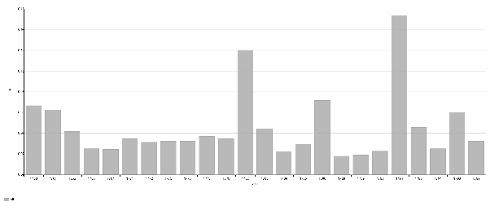

**Abb. 3.31** SPARQL-Abfrage: Wie hat sich das Thema “happiness | Glück | bonheur” in diachroner Betrachtung entwickelt? Die dargestellten Werte sind relativ zur gesamten Romanproduktion, https://tinyurl.com/2pbevmr4.

# 9 3.3.4 Federation: Mit welchen Handlungsorten ist das Themenkonzept “sentimentalisme” verknüpft?

Der Wissensgraph ermöglicht es Themenkonzepte und Handlungsorte in Kombination abzufragen. Wir können beispielsweise betrachten, wo französische Romane, die mit dem Thema “sentimentalisme” (Empfindsamkeit) verknüpft sind – quantitativ betrachtet – häufig spielen. Möchte man die Ergebnisse auf einer Landkarte darstellen, ist dies möglich, indem man eine sogenannte “Federated Query” ausführt, die auf mehreren Knowledge Graphen (hier: dem MiMoText-Graphen und Wikidata) ausgeführt wird. Eine föderierte SPARQL-Abfrage ist eine SPARQL-Abfrage, die in mehreren Wissensgraphen gespeicherte Daten miteinander kombiniert [(Prud’hommeaux / Buil-Aranda 2013)](https://www.zotero.org/google-docs/?Upsx2m).

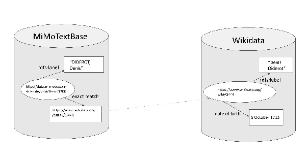

Abb. 3.32 Schematische Darstellung der Verknüpfung zweier Wissensgraphen. Die Werte des kontrollierten Vokabulars wurden für Orte, Personen und Werke mithilfe des Programms OpenRefine [(Huynh 2010)](https://www.zotero.org/google-docs/?yEBsnD) auf Wikidata-Entitäten gematched und mit der Property P13 (exact match) in den Graphen eingespeist, Query: https://tinyurl.com/2cuoyyf9. Dies ist eine Voraussetzung für “Federated Queries”.

Voraussetzung für eine föderierte Abfrage ist ein Mapping der Entitäten (in diesem Fall: Entitäten des Ortes) von Knowledge Graph zu Knowledge Graph. Im MiMoText-Graphen wird dies mit der Property exact match (P13)ausgedrückt. 484 Entitäten des Ortes wurden im lokalen Wissensgraphen mit dem Wikidata-Graphen über diese Property verbunden.  
Die entsprechenden Prefixes beider Graphen müssen in der Query angegeben und definiert werden. Mit SERVICE <https://query.wikidata.org/sparql> wird der zu nutzende zweite Knowledge Graph (in diesem Fall Wikidata, das für geographische Entitäten Angaben zu Längen- und Breitengraden enthält) angegeben.

Mit #defaultView:Map wird die Ausgabe als Landkarte ausgelöst, mit “layer”:”?themeLabel” wird angegeben, dass alle Themenwerte als auszuwählende Layer (anwählbar über Klick) auf der Karte visualisiert ausgegeben werden (s. Abb 3.33).

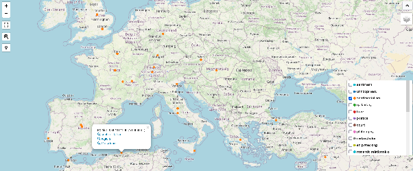

**Abb. 3.33** Handlungsorte aller Romane 1751-1800, die von “sentimentalisme” handeln (Ausschnitt), https://tinyurl.com/2dqa787l, mit Markercluster: https://tinyurl.com/24tfbu2y.

Im Ergebnis zeigen sich als häufige Handlungsorte des französischen empfindsamen Romans des 18. Jahrhunderts Frankreich, England und Italien. Daneben kommen auch singuläre Werte wie Aleppo, Algiers, Ägypten, Ungarn, Schweiz, Syrakus oder Österreich als Handlungsorte von Romanen mit Thema “sentimentalisme” vor.  
Umgekehrt lassen sich auch ausgehend von einem Handlungsort, beispielsweise ländlicher Raum, Muster in den Themenkonzepten abfragen.[^20] Für Werke, die im ländlichen Raum spielen, zeigen sich Empfindsamkeit, Gefühl, Liebe und Unglück als häufigste Werte. Weitere Muster und Abfragen zu Raumkonzepten werden in Kapitel 4 diskutiert.

# 10 3.3.5 Unterscheiden sich Werke männlicher und weiblicher Autor:innen hinsichtlich thematischer Inhalte?

Wie Matthew Jockers in Macroanalysis im Kapitel *Theme* ausführt, kann es lohnenswert sein, die gefundenen Topics je nach Geschlecht aufgeschlüsselt zu betrachten. Er konnte für sein Korpus britischer, irischer und us-amerikanischer Literatur des 19. Jahrhunderts zeigen, dass das Thema “Villains and Traitors” oder “Enemies” häufiger in Werken männlicher Autoren vorkommen, “Affection and Happiness” oder “Infants” jedoch makrostrukturell betrachtet Themen sind, die häufiger von weiblichen Autorinnen behandelt werden (Jockers 2013, pp. 118- 153).  
Analog können wir in unseren Daten betrachten, wie sich die Themen-Statements im französischen Roman des 18. Jahrhundert hinsichtlich des Geschlechts von Autor oder Autorin verhalten. Im Unterschied zu Jockers betrachten wir dabei vereint Themen, die sowohl aus Topic Modeling als auch aus bibliographischen Metadaten hervorgegangen sind.

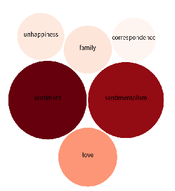

**Abb. 3.34** Abfrage der Themenwerte für weibliche Autorinnen: https://w.wiki/CoT5 NEU (top5): https://w.wiki/CoTX , visualisiert mit https://dataviz.toolforge.org/.

Im Ergebnis der häufigsten Themenwerte zeigt sich dabei, dass bei männlichen[^21] Autoren die fünf häufigsten Themenwerte sentiment (176), sentimentalism (172), travel (121), love (117) und unhappiness (84) sind. Im Unterschied dazu sind bei den weiblichen Autor:innen die fünf häufigsten Themenwerte sentiment (64), sentimentalism (60), love (36), family (24) und unhappiness (23).  
Während die Themen des Gefühls und Empfindsamkeit sowohl von männlichen als auch weiblichen Autor:innen häufig behandelt werden, zeigt sich, dass das Thema Reise bei den männlichen Autoren das dritthäufigste ist, während das Thema Liebe bei den weiblichen Autorinnen als dritthäufigstes auftritt.

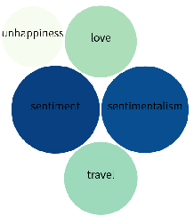

**Abb. 3.35** Abfrage der Themenwerte für männliche Autoren: https://w.wiki/CoT8 , neu (top5): https://w.wiki/CoTZ , visualisiert mit https://dataviz.toolforge.org/.

# 11 Buchgeschichte und Themen: Welche Muster lassen sich in der Abfrage der Buchformate erkennen?

Eine Übersichts-Abfrage zeigt die Vielfalt der verwendeten Buchformate an.[^24] Die Formate in-12 (Duodez) und in-18 (Oktodez) basieren auf der Art, wie ein Druckbogen gefaltet wird, um Buchseiten zu erzeugen. Im in-12-Format wird der Druckbogen in zwölf gleich große Blätter gefaltet, was größere Seiten ergibt als beim in-18-Format, bei dem der Druckbogen in 18 Blätter gefaltet wird. Dadurch sind Bücher im in-12-Format größer als Bücher im in-18-Format. Hinsichtlich der Frage der thematischen Statements können wir nun fragen, welche Buchformate für das Thema ‘Reise’ auftreten: https://tinyurl.com/2yss5yys. Das Ergebnis ist zunächst wenig aussagekräftig, da eine große Vielzahl an Stringvarianten der Buchformate zurückgegeben wird.  
Da die Strings in ihrer detaillierten Beschreibung ein aufgesplittertes Bild aufzeigen, können wir in einer weitergehenden Abfrage mithilfe regulärer Ausdrücke in Formate in-12 oder in-18 gruppieren (Abb. 3.37.).

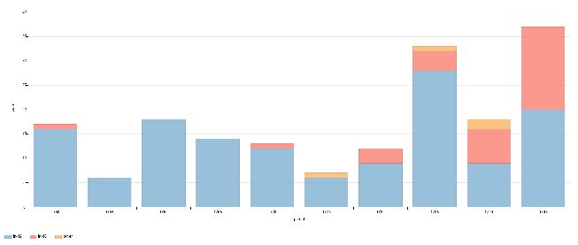

**Abb. 3.37:** Reiseromane und ihre Buchformate (in-12, in-18), rot: in-18, blau: in-12, https://tinyurl.com/255fsl3f, NEU: https://tinyurl.com/29zsygh3.

Die Abfrage zeigt, dass der Reiseroman zunehmend auch in kleineren Buchformaten wie in-18 (Abb. 3.37, rote Farbe) verlegt wird. Auch übergeordnet lässt sich erkennen, dass zunehmend kleinere und vielfältigere Buchformate im Zeitverlauf zunehmen (Abb. 3.38).

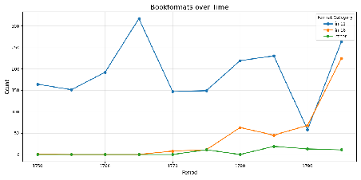

**Abb. 3.38** : Buchformate in diachroner Betrachtung (in-12, in-18).

Kleinere Buchformate ermöglichen eine von Bibliotheken und ähnlichen Institutionen unabhängige Lektüre, unterwegs, auf Reisen, in der Kutsche, in der Natur. Größere Buchformate haben jedoch auch ein größeres symbolisches Gewicht, ein größeres Prestige.[^25]

[figure not shown]

**Abb. 3.39** Jean-Jacques Rousseau, Gravure d’Hippolyte Huet d’après un tableau de Joseph Albrier XVIIIe siècle. BnF, Musique, fonds estampes, Rousseau J.-J. © Bibliothèque nationale de France

Die aggregierten Daten deuten darauf hin, dass sich die kleineren Buchformate zunehmend durchsetzen. Kleinere Buchformate sind kostengünstiger und tragen somit auch zu einer Demokratisierung des Lesens bei. Breite Bevölkerungsschichten, die auch zunehmend alphabetisiert sind, haben im 18. Jahrhundert Zugang zu Büchern. Nach wie vor lässt sich jedoch auch erkennen, dass in-12 ein verbreitetes Buchformat war, da sich hier Lesbarkeit und Handlichkeit gut die Waagschale hielten. Insgesamt konnte die Zunahme an kompakten Buchformaten auch zu den Idealen der Aufklärung des demokratischen Zugangs zur Bildung aller Schichten beitragen.  
Wie Carla Hesse betont, bedeuten die Französische Revolution und die Befreiung der Presse nicht nur das Ende der Zensur, sondern eine tiefgreifende Demokratisierung des gesamten Buchwesens, von Druckereien über den Verkauf von Büchern bis zur Lektüre von Büchern: “By 1793 anyone could own a printing press or engage in publishing and bookselling.” [(Hesse 2024, 3)](https://www.zotero.org/google-docs/?UCvpoj). Die Rupturen im Druckerei und Verlagswesen durch die Revolution ermöglichte es den Bürgerinnen und Bürgern einen demokratischen Zugang zu Produktionsmitteln und somit ihre Gedanken und Meinungen über den Zugang zu Druckereien in Umlauf zu bringen und in die Welt zu tragen:  
In 1789, revolutionaries in France embarked on a cultural experiment that radically  
transformed the most basic elements of French literary civilization by liberating the printing and publishing world from the corporate institutions of the absolutist State and implementing a system of free-market exchange in the world of ideas.  
[(Hesse 2024, 1)](https://www.zotero.org/google-docs/?UCvpoj)  
Im Zuge der Revolution werden die alten Gilden zerschlagen, Zensur und Monopole des Buchmarktes abgeschafft, hin zu einem breiteren Zugang zu Produktion und Vertrieb von Büchern. Dieser Wandel begünstigte die Verbreitung kostengünstigerer und kompakterer Buchformate, die nicht nur durch niedrigere Anschaffungskosten, sondern auch durch ihre höhere Transportabilität die Verbreitung von Wissen und Ideen förderten.

# 12

# 13

# 14 3.3.6 Welche Themen-Cluster hat der Algorithmus im Gegensatz zur menschlichen Lektüre identifiziert?

Wie in den vorangegangenen Kapiteln beschrieben, wurden thematische Statements aus zwei unterschiedlichen Quellen extrahiert: Erstens aus bibliographischen Metadaten einer Bibliographie aller erzählenden französischen Werke 1751-1800, die 1977 veröffentlicht wurde. Die darin enthaltenen Stichworte zu Themen sind aus menschlicher Lektüre hervorgegangen. Die zweite Quelle sind französische Romane im Volltext, aus denen mithilfe von unüberwachtem Machine Learning distinktive Topics extrahiert wurden. Die extrahierten Themenwerte aus beiden Methoden wurden auf ein gemeinsames kontrolliertes Vokabular an Themen gemappt, sodass sie durch diese Vereinheitlichung vergleichbar werden.  
Wir können nun im Mensch-Maschine-Vergleich betrachten, welche thematischen Werte der Algorithmus und welche Werte der Mensch in den Romanen dieser Zeit findet.[^26] Ein Vergleich ermöglicht dabei auch eine Einschätzung dessen, was in der “Black Box” Topic Modeling abläuft. Wie bereits Turing zum Thema Machine Learning schreibt “An important feature of a learning machine is that its teacher will often be very largely ignorant of quite what is going on inside, although he may still be able to some extent to predict his pupil’s behaviour” [(Turing 1950: 458)](https://www.zotero.org/google-docs/?3O6e4I). Auch wenn Forschende viele Möglichkeiten haben, das Topic Modeling Ergebnis zu steuern (über die Vorverarbeitung, über die gewählte Anzahl der Topics usw.)[^27] bleibt der Algorithmus unüberwacht, d.h. zu einem gewissen Grad eine “Black Box”. Daher soll im Kapitel “Extraktion thematischer Statements” abschließend in zwei Queries verglichen werden, wie sich die aggregierten Themenwerte je nach Provenienz des Statements (Algorithmus oder bibliographische Metadaten) zueinander verhalten. Zunächst eine SPARQL-Abfrage (Abb. 3.34), die nach den Themenwerten aller Romane fragt, die als Referenz die *Bibliographie du genre romanesque français* (Q1) [(Martin / Mylne / Frautschi 1977)](https://www.zotero.org/google-docs/?7VHQoA) haben.

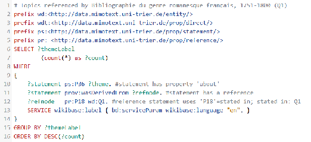

**Abb. 3.34** SPARQL-Query nach Themen im Korpus, die aus den bibliographischen Metadaten (Q1)  
hervorgegangen sind: https://tinyurl.com/2lp3le8a.

In der Abfrage wird nach allen Statements gefragt, die sich auf einen Themenwert (P36) beziehen. Damit wir als Ergebnis lediglich die Statements, die als Referenz die Bibliographie (Q1) haben, erhalten, ist es nötig, den ?refnode (Abb. 3.34) zu spezifizieren. Es wird in der Query nach allen ?refnode Items gefragt, die als Property “stated in” (P18) die Entität “*Bibliographie du genre romanesque français*” (Q1) haben. Zur Veranschaulichung dazu eine schematische Übersicht der Modellierung der Referenzierungen via Reference Node (Abb. 3.35).

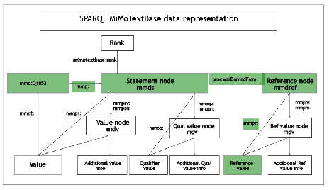

**Abb. 3.35** Schematische Übersicht des Reference Node, https://mimotext.github.io/MiMoTextBase_Tutorial/aboutMiMoTextBase.html.  
Analog zu der [Abfrage](https://tinyurl.com/2lp3le8a) nach thematischen Statements, die die Bibliographie (Q1) als Quelle haben, können wir auch eine [Abfrage](https://tinyurl.com/267c55l4) formulieren, die alle thematischen Statements aggregiert, die aus dem Topic Modeling (Q21) hervorgegangen sind. In der folgenden Tabelle sehen wir die häufigsten Werte aus diesen beiden Queries:

**Tabelle: Themenwerte im Ranking, aufgesplittet nach Quelle.**

| *Themenwerte aus menschlich generierten bibliographischen Metadaten, Top 15* | *Themenwerte aus unüberwachtem Topic Modeling Algorithmus, Top 15* |
| --- | --- |
| sentimentalism | Topic 0:[temps paraître encore] |
| sentiment | happiness |
| travel | sentiment |
| unhappiness | love |
| love | interaction |
| gallantry | night |
| virtue | mourning |
| philosophy | attraction |
| politics | personality |
| family | death |
| melancholia | family |
| court | correspondence |
| miracle | philosophy |
| libertinism | romantic relationship |
| eroticism | travel |

Themenwerte des gesamten Korpus, Bibliographie (Q1) als Referenz: https://tinyurl.com/2lp3le8a und Themenwerte mit Topic Modeling (Q21) als Referenz https://tinyurl.com/2bej58yg.

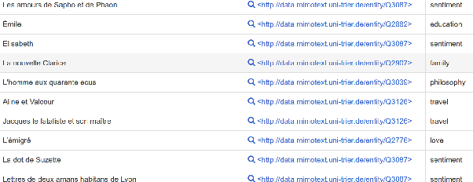

**Abb. 3.36** Ausschnitt aus der Ergebnisliste von Werken, bei denen sowohl Topic Modeling als auch Bibliographie zu dem gleichen Ergebnis als Themenwert kommen, https://tinyurl.com/2msqja4p.

## 14.1 3.4 Zusammenfassung und Ausblick

Die Extraktion von thematischen RDF-Tripel ermöglichte es, einen Grundstock an relevanten Aussagen zu den Primärtexten in den Wissensgraphen einzuspeisen. Es wurden dazu aus zwei verschiedenen Quellen thematische Statements extrahiert: einerseits aus thematischen Stichwörtern in bibliographischen Metadaten, andererseits mithilfe von Topic Modeling auf französischen Volltexten (Romanen).

In Kombination mit Erzählformen, Textlänge, Publikationsdatum und Autor:innen, Figuren, Handlungsorten und der Tonalität der Romane könnten sich potentiell weitere Bezüge erheben lassen. Der Fallstudie der Buchformate in Kombination mit dem Thema ‘Reise’ skizziert dies. Im Ausblick ist bezüglich der gewählten Methode Topic Modeling anzumerken, dass man auch weitere Ansätze neben LDA explorieren könnte, das Python-Paket BERTopic [(Grootendorst 2022)](https://www.zotero.org/google-docs/?PjGTIL) oder auch die Themenextraxtion mit LLMs [(OpenAI et al. 2024)](https://www.zotero.org/google-docs/?xGWMwK) könnten in dieser Hinsicht vielversprechend sein.

### 14.1.1

### 14.1.2 Appendix A: Ausschnitt aus den Topics mit Top Topic Words

**Amour_Sentiment**

Topic 6 : amour, cœur, aimer, point, sentiment, âme, bonheur, passion, seul, vertu, jamais, heureux, amant, ami, croire, tendre, connaître, charme, amitié, objet

**Art**

Topic 27: livre, ouvrage, lire, auteur, histoire, grand, esprit, temps, goût, pièce, lecture, roman, genre, écrire, tableau, théâtre, beau, voir, musique, vérité

**Éducation_Enfance**

Topic 24: père, fille, mère, enfant, fil|fils, sœur, frère, cher, voir, bon, femme, jeune, mari, saint, famille, donner, mariage, jour, petit, aimer

**Locus Amoenus**

Topic 7: amour, beau, amant, plaisir, œil, doux, fleur, cœur, berger, jeune, beauté, tendre, voir, chanter, encore, main, charme, berger|bergère, feu, jour

**Monarchie**

Topic 3: roi, prince, peuple, grand, gloire, ennemi, sujet, souverain, guerre, monarque, trône, patrie, troupe, empire, porter, cour, chef, arme, ordre, honneur

**Nature**

Topic 8: terre, arbre, eau, montagne, lieu, soleil, mer, petit, île, élever, pied, rocher, couvrir, grand, fruit, forêt, bord, tour, là, bois

**Nuit**

Topic 29: heure, chambre, sortir, porte, passer, lit, entrer, nuit, entendre, maison, mettre, main, arriver, lever, demander, matin, coucher, attendre, jour, soir

**Philosophie**

Topic 11: homme, nature, loi, vertu, peuple, seul, mal, point, vice, société, humain, principe, action, devenir, droit, raison, chose, donner, préjugé, naître

**Voyage**

Topic 13: arriver, homme, ville, jour, partir, voir, cheval, route, suivre, passer, jeune, femme, grand, temps, aventure, apprendre, donner, recevoir, conduire, maison

**Appendix B: Liste der Werke der Topic Modeling Analyse**

[output not shown]

[output cut: 61 more lines]

## 14.2

## 14.3 Referenzen

[**Binder, Jeffrey M.** / **Jennings, Collin** (2014): “Visibility and meaning in topic models and 18th-century subject indexes”, in: *Literary and Linguistic Computing* 29 (3): 405–411. 10.1093/llc/fqu017.](https://www.zotero.org/google-docs/?fqBRoB)  
[**Blay, Michel** / **Junod, Philippe** / **Roche, Daniel** / **Collectif** (1997): *Dictionnaire européen des Lumières*. Paris: PUF.](https://www.zotero.org/google-docs/?fqBRoB)  
[**Blei, David M.** (2011): *Introduction to Probabilistic Topic Models*. in: *Communications of the ACM*. New York. 1–16.](https://www.zotero.org/google-docs/?fqBRoB)  
[**Blei, David M.** (2012): “Probabilistic topic models”, in: *Communications of the ACM* 55 (4): 77. 10.1145/2133806.2133826.](https://www.zotero.org/google-docs/?fqBRoB)  
[**Blei, David M.** / **Ng, Andrew Y.** / **Jordan, Michael** (2003): “Latent dirichlet allocation”, in: 3: 993–1022.](https://www.zotero.org/google-docs/?fqBRoB)  
[**Bond, Elizabeth Andrews** / **Bond, Robert M.** (2020): “Topic modelling the French pre-Revolutionary press” in: Burrows, Simon / Roe, Glenn (eds.): *Digitizing Enlightenment : Digital Humanities and the Transformation of Eighteenth-Century Studies*. Oxford: LIVERPOOL UNIV Press 247–276.](https://www.zotero.org/google-docs/?fqBRoB)  
[**Burnard, Lou** (2014): *What is the Text Encoding Initiative? : How to add intelligent markup to digital resources*. (= Encyclopédie numérique) Marseille: OpenEdition Press.](https://www.zotero.org/google-docs/?fqBRoB)  
[**Camus, Michel** (ed.) (1985): *Œuvres anonymes du XVIII siècle*. (= L’Enfer de la Bibliothèque nationale 3-<5, 6 >) Paris: Fayard.](https://www.zotero.org/google-docs/?fqBRoB)  
[**Chang, Jonathan** / **Boyd-Graber, Jordan** / **Wang, Chong** / **Gerrish, Sean** / **Blei, David M.** (2009): *Reading Tea Leaves: How Humans Interpret Topic Models*. in: *NIPS*. http://books.nips.cc/papers/files/nips22/NIPS2009_0125.pdf.](https://www.zotero.org/google-docs/?fqBRoB)  
[**Condorcet, Jean-Antoine-Nicolas de Caritat marquis de** (1847): *De l’influence de la Révolution d’Amérique sur l’Europe ([Reprod.]) / [par Condorcet] ; [publ. par A. Condorcet O’Connor,… et M. F. Arago,…]*.](https://www.zotero.org/google-docs/?fqBRoB)  
[**Da, Nan Z.** (2019): “The Computational Case against Computational Literary Studies”, in: *Critical Inquiry* 45 (3): 601–639. 10.1086/702594.](https://www.zotero.org/google-docs/?fqBRoB)  
[**Diderot, Denis** (1875): *Œuvres complètes*. Wikisource, Paris: Garnier.](https://www.zotero.org/google-docs/?fqBRoB)  
[**Dörpinghaus, Jens** (2022): “Wissensgraphen: Interdisziplinäre Perspektiven für Linked Data in den Geistes- und Sozialwissenschaften”, in: *Zeitschrift für digitale Geisteswissenschaften* 07: 10.17175/2022_011.](https://www.zotero.org/google-docs/?fqBRoB)  
[**Du, Keli** (2019): *A Survey On LDA Topic Modeling In Digital Humanities*. DataverseNL. https://dataverse.nl/dataset.xhtml?persistentId=doi:10.34894/H9UYPI [letzter Zugriff 28. November 2022].](https://www.zotero.org/google-docs/?fqBRoB)  
[**Du, Keli** / **Dudar, Julia** / **Rok, Cora** / **Schöch, Christof** (2021): *Zeta & Eta: An Exploration and Evaluation of two Dispersion-based Measures of Distinctiveness*. in: *Proceedings of the Conference on Computational Humanities Research 2021*. Amsterdam. http://ceur-ws.org/Vol-2989/short_paper11.pdf.](https://www.zotero.org/google-docs/?fqBRoB)  
[**Elmas, Ferhat** (2016): *gender-guesser*. https://github.com/lead-ratings/gender-guesser [letzter Zugriff 9. Dezember 2022].](https://www.zotero.org/google-docs/?fqBRoB)  
[**Erlin, Matt** (2014): “The Location of Literary History: Topic Modeling, Network Analysis, and the German Novel, 1731–1864” in: Erlin, Matt / Tatlock, Lynne (eds.): *Distant Readings: Topologies of German Culture in the Long Nineteenth Century* (= Studies in German Literature, Linguistics, and Culture). NED-New edition Boydell & Brewer 55–90.](https://www.zotero.org/google-docs/?fqBRoB)  
[**Firth, John R.** (1957): “A Synopsis of Linguistic Theory, 1930-1955” in: *Studies in Linguistic Analysis*. Oxford: Blackwell 1–32.](https://www.zotero.org/google-docs/?fqBRoB)  
**Freedman, J.** (2012) *Books Without Borders in Enlightenment Europe: French Cosmopolitanism and*  
*German Literary Markets*. University of Pennsylvania Press.  
[**Grootendorst, Maarten** (2022): *BERTopic*. https://github.com/MaartenGr/BERTopic [letzter Zugriff 29. November 2022].](https://www.zotero.org/google-docs/?fqBRoB)  
[**Heiden, Serge** (2010): *The TXM Platform: Building Open-Source Textual Analysis Software Compatible with the TEI Encoding Scheme*. http://halshs.archives-ouvertes.fr/halshs-00549764/en [letzter Zugriff 3. August 2011].](https://www.zotero.org/google-docs/?fqBRoB)  
[**Hinzmann, Maria** (2022): *MiMoText ontology*. Trier: Trier Center for Digital Humanities. https://github.com/MiMoText/ontology.](https://www.zotero.org/google-docs/?fqBRoB)  
[**Honnibal, Matthew** / **Montani, Ines** (2017): *spaCy 2: Natural language understanding with Bloom embeddings, convolutional neural networks and incremental parsing*.](https://www.zotero.org/google-docs/?fqBRoB)  
[**Huet, Pierre Daniel** (1670): *Traité De L’Origine des Romans*. J.B. Metzler Stuttgart.](https://www.zotero.org/google-docs/?fqBRoB)  
[**Hunt, Lynn** (2008): *Inventing Human Rights: A History*. New York ; London: W. W. Norton & Company.](https://www.zotero.org/google-docs/?fqBRoB)  
[**Huynh, David** (2010): *OpenRefine*. OpenRefine. https://github.com/OpenRefine/OpenRefine.](https://www.zotero.org/google-docs/?fqBRoB)  
[**Jockers, Matthew L.** (2013): *Macroanalysis: Digital Methods and Literary History*. Urbana, Ill [u.a.]: University of Illinois Press.](https://www.zotero.org/google-docs/?fqBRoB)  
[**Jockers, Matthew L.** (2014): “Topic Modeling” in: Jockers, Matthew L. (ed.): *Text Analysis with R for Students of Literature* (= Quantitative Methods in the Humanities and Social Sciences). Cham: Springer International Publishing 135–159. 10.1007/978-3-319-03164-4_13.](https://www.zotero.org/google-docs/?fqBRoB)  
[**Jockers, Matthew L.** / **Mimno, David** (2013): “Significant themes in 19th-century literature”, in: *Poetics* 41 (6): 750–769. 10.1016/j.poetic.2013.08.005.](https://www.zotero.org/google-docs/?fqBRoB)  
[**Klee, Anne** / **Hinzmann, Maria** (2021): *MiMoText/vocabularies*. Mining and Modeling Text (MiMoText). https://github.com/MiMoText/vocabularies/blob/65acb008838fc13044aac554e05b3c2bbccbd12f/Themenvokabular.tsv [letzter Zugriff 2. Juli 2021].](https://www.zotero.org/google-docs/?fqBRoB)  
[**Klee, Anne** / **Röttgermann, Julia** (2020): *Doing topic modeling on French 18th century novels in the context of MiMoText project [Data set]*. https://github.com/MiMoText/topicmodeling.](https://www.zotero.org/google-docs/?fqBRoB)  
[**Lamarque, Peter** (2008): *The Philosophy of Literature*. Malden, MA, USA: John Wiley & Sons.](https://www.zotero.org/google-docs/?fqBRoB)  
[**Lassila, Ora** / **Swick, Ralph R.** (1999): *Resource Description Framework (RDF) Model and Syntax Specification*. https://www.w3.org/TR/1999/REC-rdf-syntax-19990222/ [letzter Zugriff 4. Januar 2023].](https://www.zotero.org/google-docs/?fqBRoB)  
[**Lou Burnard** / **Carolin Odebrecht** (2019): *COST-ELTeC/Schemas: level0 and level1 release*. Zenodo. https://zenodo.org/record/3490758 [letzter Zugriff 27. Januar 2021].](https://www.zotero.org/google-docs/?fqBRoB)  
[**Lüschow, Andreas** (2019): *Bibliographie du genre romanesque français, 1751-1800: RDF model [Data set]*. Trier: Trier University.](https://www.zotero.org/google-docs/?fqBRoB) http://doi.org/10.5281/zenodo.3401428[.](https://www.zotero.org/google-docs/?fqBRoB)  
**Maier, Daniel, A. Waldherr, P. Miltner, G. Wiedemann, A. Niekler, A. Keinert, B. Pfetsch, G. Heyer, U. Reber, and T. Häussler** ( 2021) “Applying LDA Topic Modeling in Communication Research: Toward a Valid and Reliable Methodology.” In *Computational Methods for Communication Science*. Routledge.  
[**Martin, Angus** / **Mylne, Vivienne** / **Frautschi, Richard L.** (1977): *Bibliographie du genre romanesque français, 1751-1800*. London: Mansell.](https://www.zotero.org/google-docs/?fqBRoB)  
[**Mauzi, Robert** (1969): *L’ idée du bonheur dans la littérature et la pensée françaises au XVIII. siècle*. 4. ed. Paris: Colin.](https://www.zotero.org/google-docs/?fqBRoB)  
[**McCallum, Andrew Kachites** (2002): *MALLET: A Machine Learning for Language Toolkit*. http://mallet.cs.umass.edu.](https://www.zotero.org/google-docs/?fqBRoB)  
[**Mueller, Andreas** (2020): *WordCloud for Python documentation — wordcloud 1.8.1 documentation*. https://amueller.github.io/word_cloud/ [letzter Zugriff 29. November 2022].](https://www.zotero.org/google-docs/?fqBRoB)  
[**Mylne, Vivienne** (1981): *The Eighteenth-Century French Novel Techniques of Illusion _(1965)*. Cambridge: Cambridge Univ. Press.](https://www.zotero.org/google-docs/?fqBRoB)  
[**Paige, Nicholas** (2018): “The Artifactuality of Narrative Form”, in: *Poetics Today* 39 (1): 41–65. 10.1215/03335372-4265059.](https://www.zotero.org/google-docs/?fqBRoB)  
[**Rehurek, Radim** / **Sojka, Petr** (2010): *Software framework for topic modelling with large corpora*. in: *The LREC 2010 Workshop on New Challenges for NLP Frameworks*. University of Malta. 45–50. http://is.muni.cz/publication/884893/en [letzter Zugriff 13. November 2016].](https://www.zotero.org/google-docs/?fqBRoB)  
[**Reul, Christian et al.** (2019): “OCR4all—An Open-Source Tool Providing a (Semi-)Automatic OCR Workflow for Historical Printings”, in: *Applied Sciences* 9 (22): 4853. 10.3390/app9224853.](https://www.zotero.org/google-docs/?fqBRoB)  
[**Rhody, Lisa M.** (2013): “Topic Modeling and Figurative Language”, in: *Journal of Digital Humanities*:](https://www.zotero.org/google-docs/?fqBRoB)  
[**Roberts, Margaret** / **Stewart, Brandon** / **Tingley, Dustin** / **Benoit, Kenneth** (2020): *stm: Estimation of the Structural Topic Model*. https://CRAN.R-project.org/package=stm [letzter Zugriff 28. November 2022].](https://www.zotero.org/google-docs/?fqBRoB)  
[**Roe, Glenn** / **Gladstone, Clovis** / **Morrissey, Robert** (2016): “Discourses and Disciplines in the Enlightenment: Topic Modeling the French Encyclopédie”, in: *Frontiers in Digital Humanities* 2: 8. 10.3389/fdigh.2015.00008.](https://www.zotero.org/google-docs/?fqBRoB)  
[**Röttgermann, Julia** (ed.) (2020): “Collection de romans français du dix-huitième siècle (1750-1800) / Eighteenth-Century French Novels (1750-1800) [dataset]”, in: *Release v0.1.0*: DOI: 10.5281/ZENODO.4061904.](https://www.zotero.org/google-docs/?fqBRoB)  
[**Röttgermann, Julia** (ed.) (2021): “Collection de romans français du dix-huitième siècle (1750-1800) / Eighteenth-Century French Novels (1750-1800) [dataset]”, in: *Release v0.2.0*: 10.5281/zenodo.5040855.](https://www.zotero.org/google-docs/?fqBRoB)  
[**Saint-Just** (2004): *Œuvres complètes*. Gallimard.](https://www.zotero.org/google-docs/?fqBRoB)  
[**Sarkar, Dipanjan** (2019): *Text analytics with Python: a practitioner’s guide to natural language processing*. Second edition New York, NY: Apress.](https://www.zotero.org/google-docs/?fqBRoB)  
[**Saussure, Ferdinand de** (1971): *Cours de linguistique générale*. Paris: Payot.](https://www.zotero.org/google-docs/?fqBRoB)  
[**Sbalchiero, Stefano** / **Eder, Maciej** (2020): “Topic modeling, long texts and the best number of topics. Some Problems and solutions”, in: *Quality & Quantity* 54 (4): 1095–1108. 10.1007/s11135-020-00976-w.](https://www.zotero.org/google-docs/?fqBRoB)  
[**Schmid, Helmut** (1994): *Probabilistic Part-of-Speech Tagging Using Decision Trees*. in: *Proceedings of International Conference on New Methods in Language Processing*. Manchester, UK. https://www.cis.uni-muenchen.de/~schmid/tools/TreeTagger/data/tree-tagger1.pdf.](https://www.zotero.org/google-docs/?fqBRoB)  
[**Schöch, Christof** (2017): “Topic Modeling Genre: An Exploration of French Classical and Enlightenment Drama”, in: *Digital Humanities Quarterly* 011 (2):.](https://www.zotero.org/google-docs/?fqBRoB)  
[**Schöch, Christof** (2018): “Zeta für die kontrastive Analyse literarischer Texte: Theorie, Implementierung, Fallstudie” in: Bernhart, Toni / Willand, Marcus / Richter, Sandra / Albrecht, Andrea (eds.): *Quantitative Ansätze in den Literatur- und Geisteswissenschaften: Systematische und historische Perspektiven*. Berlin ; Boston: De Gruyter 77–94. 10.1515/9783110523300-004.](https://www.zotero.org/google-docs/?fqBRoB)  
[**Schöch, Christof** (2020): *Simple Topic Modeling pipeline using TextBlob and gensim [Data set]*. https://github.com/dh-trier/topicmodeling/.](https://www.zotero.org/google-docs/?fqBRoB)  
[**Schröter, Julian** / **Du, Keli** (2022): “Validating Topic Modeling as a Method of Analyzing Sujet and Theme”, in: *Journal of Computational Literary Studies* 1 (1): https://doi.org/10.48694/jcls.91.](https://www.zotero.org/google-docs/?fqBRoB)  
[**Shadrova, Anna** (2021): “Topic models do not model topics: epistemological remarks and steps towards best practices”, in: *Journal of Data Mining and Digital Humanities* 2021: 10.46298/jdmdh.7595.](https://www.zotero.org/google-docs/?fqBRoB)  
[**Sievert, Carson** / **Shirley, Kenneth** (2014): *LDAvis: A method for visualizing and interpreting topics*. in: *Proceedings of the Workshop on Interactive Language Learning, Visualization, and Interfaces*. Baltimore, Maryland, USA: Association for Computational Linguistics. 63–70. https://aclanthology.org/W14-3110 [letzter Zugriff 14. Dezember 2022].](https://www.zotero.org/google-docs/?fqBRoB)  
[**Singhal, Amit** (2012): *Introducing the Knowledge Graph: things, not strings*. in: *Google*. https://blog.google/products/search/introducing-knowledge-graph-things-not/ [letzter Zugriff 2. August 2022].](https://www.zotero.org/google-docs/?fqBRoB)  
[**Souza, Marli Aparecida Rocha de** / **Wall, Marilene Loewen** / **Thuler, Andrea Cristina de Morais Chaves** / **Lowen, Ingrid Margareth Voth** / **Peres, Aida Maris** (2018): “The use of IRAMUTEQ software for data analysis in qualitative research”, in: *Revista da Escola de Enfermagem da USP* 52: 10.1590/S1980-220X2017015003353.](https://www.zotero.org/google-docs/?fqBRoB)  
[**Spiller, Robert E.** (1963): “Is Literary History Obsolete?”, in: *College English* 24 (5): 345–351. 10.2307/373549.](https://www.zotero.org/google-docs/?fqBRoB)  
[**Steffes, Moritz** (2021): *MiMoText/Wikibase-Bot*. https://github.com/MiMoText/Wikibase-Bot [letzter Zugriff 20. Dezember 2022].](https://www.zotero.org/google-docs/?fqBRoB)  
[**Stiegler, Bernd** (2018): “Zimmerreisen” in: Scholz, Susanne / Vedder, Ulrike (eds.): *Handbuch Literatur & Materielle Kultur* (= Handbücher zur kulturwissenschaftlichen Philologie 6). Berlin ; Boston: De Gruyter 357–364. 10.1515/9783110416497-041.](https://www.zotero.org/google-docs/?fqBRoB)  
[**Thomä, Dieter** (2011): “Glück, Revolution und revolutionäres Denken im 18. Jahrhundert. Philosophisch-politische Diskurse in den USA und in Frankreich” in: Thomä, Dieter / Henning, Christoph / Mitscherlich-Schönherr, Olivia (eds.): *Glück: Ein interdisziplinäres Handbuch*. Stuttgart: J.B. Metzler 172–182. 10.1007/978-3-476-00372-0_34.](https://www.zotero.org/google-docs/?fqBRoB)  
[**Turing, A. M.** (1950): “I.—Computing Machinery and Intelligence”, in: *Mind* LIX (236): 433–460. 10.1093/mind/LIX.236.433.](https://www.zotero.org/google-docs/?fqBRoB)  
[**Uglanova, Inna** / **Gius, Evelyn** (2020): *The Order of Things. A Study on Topic Modelling of Literary Texts*. in: Karsdorp, Folgert / McGillivray, Barbara / Nerghes, Adina / Wevers, Melvin (eds.): *CHR 2020: Workshop on Computational Humanities Research, November 18–20, 2020*. Amsterdam, The Netherlands. 57–76.](https://www.zotero.org/google-docs/?fqBRoB)  
[**Underwood, Ted** (2012): *Topic modeling made just simple enough.* in: *The Stone and the Shell*. https://tedunderwood.com/2012/04/07/topic-modeling-made-just-simple-enough/ [letzter Zugriff 23. Februar 2021].](https://www.zotero.org/google-docs/?fqBRoB)  
[**Weitin, Thomas** / **Herget, Katharina** (2017): “Falkentopics”, in: *Zeitschrift für Literaturwissenschaft und Linguistik* 47 (1): 29–48. 10.1007/s41244-017-0049-3.](https://www.zotero.org/google-docs/?fqBRoB)  
[**Wiedemann, Gregor** (2022): “The World of Topic Modeling in R”, in: *M&K Medien & Kommunikationswissenschaft* 70 (3): 286–291. 10.5771/1615-634X-2022-3-286.](https://www.zotero.org/google-docs/?fqBRoB)  
[**Wiedemann, Gregor** / **Fedtke, Cornelia** (2021): “From frequency counts to contextualized word embeddings: The Saussurean turn in automatic content analysis” in: Engel, Uwe / Quan-Haase, Anabel / Liu, Sunny / Lyberg, Lars (eds.): *Handbook of Computational Social Science. Data Science, Statistical Modelling, and Machine Learning Methods*. Abingdon, Oxon ; New York: Routledge 366–385. 10.4324/9781003025245-25.](https://www.zotero.org/google-docs/?fqBRoB)

## 14.4

## 14.5 Appendix: SPARQL-Queries

##### 14.5.0.0.1 **3.1** Themenwerte (mehr als zweimal vorkommend) im Wissensgraphen als BarChart, https://tinyurl.com/2b6tulbg.

prefix wd:<http://data.mimotext.uni-trier.de/entity/>  
prefix wdt:<http://data.mimotext.uni-trier.de/prop/direct/>

#defaultView:BarChart  
Select (str(SAMPLE(year(?date))) as ?year) (count(?themelabel) as ?count) ?themelabel  
WHERE{  
?item wdt:P36 ?theme.  
?theme rdfs:label ?themelabel .  
?item wdt:P9 ?date .  
FILTER(lang(?themelabel) = “en”)  
BIND(str(year(?date)) as ?year)  
SERVICE wikibase:label {bd:serviceParam wikibase:language “{AUTO_LANGUAGE}”,“en” .}  
}

GROUP BY ?themelabel ?year ?count  
having (?count> 2)

##### 14.5.0.0.2 3.17 Themenwerte als Co-Nodes: Welche Themen kommen häufig gemeinsam mit dem Wert ‘Familie’ vor? Endpoint ist Wikidata: https://w.wiki/Dgi9.

SELECT ?node1 ?node2 ?node1Label ?node2Label ?pdate ?workLabel ?authorLabel (COUNT(?work) AS ?count) WHERE {  
?work wdt:P12047 ?id;  
wdt:P921 ?node1, ?node2.  
FILTER(?node1 != ?node2) # Selbstreferenzen ausschließen  
FILTER(?node1 = wd:Q8436) # Thema ‘Familie’  
OPTIONAL { ?work wdt:P577 ?pdate. }  
OPTIONAL { ?work wdt:P50 ?author. }  
SERVICE wikibase:label { bd:serviceParam wikibase:language “en”. }  
}  
GROUP BY ?node1 ?node2 ?node1Label ?node2Label ?pdate ?workLabel ?authorLabel  
ORDER BY DESC (?count)  
HAVING (?count >= 5)  
ORDER BY DESC(?count)

**3.26** Was sind die häufigsten Themenwerte des Briefromans? https://tinyurl.com/23x9u774.

# Thematic concepts for epistolary novels  
#defaultView:BubbleChart  
PREFIX wd:<http://data.mimotext.uni-trier.de/entity/>  
PREFIX wdt:<http://data.mimotext.uni-trier.de/prop/direct/>

SELECT ?themeName (count (?themeName) as ?count)  
WHERE {  
?work wdt:P36 ?theme . # work has theme  
?work wdt:P33 wd:Q42.  
?theme rdfs:label ?themeName . # get theme label (not only Link to theme)  
FILTER(LANG(?themeName) = “en”) # other options: “fr”, “de”.  
}

group by ?themeName  
having (count(?themeName) > 10)  
order by desc (?count)

##### 14.5.0.0.3

##### 14.5.0.0.4 **3.15** Themenwerte aus bibliographischen Metadaten und Topic Modeling, https://tinyurl.com/2945v7bp.

# Themes as BarChart (all sources of thematic statements)  
prefix wd:<http://data.mimotext.uni-trier.de/entity/>  
prefix wdt:<http://data.mimotext.uni-trier.de/prop/direct/>

#defaultView:BarChart  
Select (str(SAMPLE(year(?date))) as ?year) (count(?themelabel) as ?count) ?themelabel  
WHERE{  
?item wdt:P36 ?theme.  
?theme rdfs:label ?themelabel .  
?item wdt:P9 ?date .  
FILTER(lang(?themelabel) = “en”)  
BIND(str(year(?date)) as ?year)  
SERVICE wikibase:label {bd:serviceParam wikibase:language “{AUTO_LANGUAGE}”,“en” .}  
}

GROUP BY ?themelabel ?year ?count  
having (?count> 1)

[^1]: MiMoText property about: http://data.mimotext.uni-trier.de/wiki/Property:P36, equivalente property dazu auf schema.org: https://schema.org/about; close match ‘main property’ auf Wikidata: https://www.wikidata.org/wiki/Property:P921.
[^2]: *Aboutness* ist in den Literaturwissenschaften, wie Peter Lamarque in “The Philosophy of Literature” darlegt, auf zwei Ebenen definiert: “In the literary context, ‘aboutness’ has two applications: at a *subject* level and at a *thematic* level” [(Lamarque 2008: 150–151)](https://www.zotero.org/google-docs/?fYRR4E). Wo genau und ob sich die Ergebnisse des Topic Modeling dazwischen verorten, ist umstritten [(Weitin / Herget 2017; Shadrova 2021; Schröter / Du 2022)](https://www.zotero.org/google-docs/?VJ0VJt).
[^3]: Für weitere und vehementere kritische Betrachtung zu Topic Modeling cf. ([Da 2019](https://www.zotero.org/google-docs/?QrZsnp)) und ([Shadrova 2021](https://www.zotero.org/google-docs/?pKkP9Q)). Shadrova schlägt als Alternative zu Topic Modeling die Software *IRaMuTeQ* [(Souza et al. 2018)](https://www.zotero.org/google-docs/?YuGENh) vor, die “multiscale reading” erlaubt und dabei die Verbindung zwischer konkreter Textrepräsentation und statistischen Clustering-Verfahren erhält [(Shadrova 2021: 20)](https://www.zotero.org/google-docs/?JenQ9w). Da hingegen kritisiert, dass Topic Modeling sehr sensitiv hinsichtlich der gewählten Parameter ist und keine Reproduzierbarkeit garantiert werden kann: “topic modeling is like a kaleidoscope that turns out something entirely different with the slightest tweaking” ([Da 2019](https://www.zotero.org/google-docs/?QrZsnp): 629).
[^4]: Ferdinand de Saussure legt dies in seinem *Cours de linguistique générale* (1916) in § 1 “Nature du signe linguistique” dar [(Saussure 1971: 98–100)](https://www.zotero.org/google-docs/?gKMOot).
[^5]: https://github.com/MiMoText/roman18/tree/master/Python-Scripts/modernization%20and%20transformation%20to%20plaintext
[^6]: Die Anzahl von 1000 Token per Chunk wurde in Anlehnung an die Pipeline von [(Schöch 2017)](https://www.zotero.org/google-docs/?dIHfO7) gewählt, der in dieser Hinsicht [(Jockers 2013: 134)](https://www.zotero.org/google-docs/?OB8Vzg) als Referenz anführt. Für eine Diskussion dieser Kennzahl (in verschiedenen Experimenten) cf. [(Sbalchiero / Eder 2020)](https://www.zotero.org/google-docs/?vTP6Vh).
[^7]: Cf. [Erlin 2014: 61](https://www.zotero.org/google-docs/?YI7pX3): “identifiying constellations of terms that co-occur in a document as large as an entire work tends to produce hazy results”.
[^8]: https://github.com/MiMoText/roman18/blob/master/XML-TEI/xml-tei_metadata.tsv
[^9]: Mallet: http://mallet.cs.umass.edu/topics.php & Gensim: https://pypi.org/project/gensim/.
[^10]: https://radimrehurek.com/gensim_3.8.3/models/wrappers/ldamallet.html
[^11]: *topicwords.csv* enthält die 50 Top-Wörter für jedes Topic, *wordprobs.csv* zeigt für jedes Lemma im Vokabular den Score für jedes Topic. *doc-topic-matrix.csv* enthält für jedes Textchunk eine Verteilung der Topics, welche in *chunkmatrix.csv* um relevante Metadaten pro Textstück ergänzt ist. Die Topicwahrscheinlichkeiten bezogen auf die Romane als Gesamttexte sind in der *mastermatrix.csv* zusammengefasst. *topicranking.csv* listet für jedes Werk die zehn wahrscheinlichsten Topics mit ihren Wahrscheinlichkeitswerten, https://github.com/MiMoText/mmt_2020-11-19_11-38.
[^12]: Zur Diskussion von werksspezifischen Topics beim Topic Modeling literarischer Texte [(cf. Weitin / Herget 2017)](https://www.zotero.org/google-docs/?nVEjzG).
[^13]: [https://pyldavis.readthedocs.io/en/latest/#](https://pyldavis.readthedocs.io/en/latest/)
[^14]: Da PyLDAVis mit dem Output der Topic Modeling-Bibliothek von Gensim arbeitet, müssen die von MALLET erstellten Ergebnisse zunächst in das entsprechende Format transformiert werden: https://github.com/MiMoText/topicmodeling/blob/master/scripts/make_overview.py.
[^15]: Die Visualisierung des hier behandelten Topic Models: [https://github.com/MiMoText/mmt_2020-11-19_11-38/blob/main/results/mmt_2020-11-19_11-38/visualization.](https://github.com/MiMoText/mmt_2020-11-19_11-38/blob/main/results/mmt_2020-11-19_11-38/visualization.html)
[^16]: Zur Dokumentation der Liste: https://github.com/MiMoText/vocabularies, letzter Zugriff 06.06.2023.
[^17]: https://github.com/MiMoText/Wikibase-Bot.
[^18]: Jockers und Mimno interessieren sich für thematische Werte in einem Korpus von 3346 englischen Romane des 19. Jahrhunderts, unter anderem analysieren sie Werke mit anonymer Autorschaft: “we compare and contrast the thematic tendencies of anonymous writers with those of known authors in order to explore the extent to which anonymity is itself a predictor of topical distributions. Here we investigate the hypothesis that works written anonymously will tend toward more controversial themes of a”religious, political, and/or nationalistic nature” [(Jockers / Mimno 2013: 3)](https://www.zotero.org/google-docs/?ffbT70).
[^19]: Die vollständige Liste mit allen Themen/Häufigkeiten der anonymen Romane im Korpus ist in dieser SPARQL-Query einsehbar: https://tinyurl.com/2fmq7bun.
[^20]: Was sind die häufigsten Themen von Romanen, die in der Provinz spielen? https://tinyurl.com/yop4lmck. Zur weiteren Diskussion von Handlungsorten im Französischen Roman 1751-1800 cf. [(Röttgermann et al. 2022)](https://www.zotero.org/google-docs/?XS0HXf)
[^21]: Die Zuordnung zu den Gender-Kategorien erfolgte mithilfe eines Python-Skriptes basierend auf den Vornamen und Titeln (‘Marquise’, ‘Abbé’ etc.) Die binäre Einteilung der Geschlechter geht von der Datenverfügbarkeit aus. Auf Wikidata sind in der Property gender mehr als zwei Geschlechter hinterlegt, jedoch ist für Autor:innen des 18. Jahrhunderts die Datenabdeckung nur für weiblich und männlich gegeben.
[^22]: Die entsprechende Wordle-Visualisierung bietet einen Einblick in die Top Topic Wörter: https://data.mimotext.uni-trier.de/wiki/File:Wordle_topic_modeling_2023_topic_034_correspondance.png.
[^23]: Im Projektverlauf wurden Personen, Orte, narrative Formen und thematische Konzepte in kontrollierte Vokabulare überführt.
[^24]: Übersicht der Buchformate im Wissensgraphen: https://tinyurl.com/268f7ymy.
[^25]: Nicht nur einfache Bürger, auch Prinzen zeigten im 18. Jahrhundert zunehmend einen *goût* für kleinere Formate, wie auch die Daten des STN, hier des Buchhändlers Virchaux zeigen: “In the past, princely book collectors had tended to fill their libraries with stately folios and quartos, monumental editions whose physical size symbolized the status of their owners; and, if any work of the late eighteenth century seemed to call for a truly monumental edition, it was the *Oeuvres* of Voltaire, the prince of the *philosophes*. Virchaux’s customers did not see it that way. For them, bigger was not necessarily better.” [(Freedman 2012, 240)](https://www.zotero.org/google-docs/?BuaDKU).
[^26]: Eine ähnliche Strategie der Validierung von Topic Modeling Ergebnisse durch den Abgleich mit menschlich generierten Themenlabels findet man hinsichtlich des Reuters-Korpus bei [(Blei, Ng, und Jordan 2003)](https://www.zotero.org/google-docs/?fafuvx) oder hinsichtlich des U.S. Supreme Court-Korpus bei [(Lauderdale und Clark 2014)](https://www.zotero.org/google-docs/?lZ6Xf9).
[^27]: Zur Frage der Optimierung der Parameter *Alpha* und *Beta* sowie der Anzahl der Iterationen des Inferenzalgorithmus *Gibbs-Samplings* cf. [(Du 2021)](https://www.zotero.org/google-docs/?broken=vszCnq).
[^28]: Zu beachten ist jedoch, dass lediglich 80 Romane einen Themenwert aus dem Topic Modeling (Q21) zugewiesen bekamen. Ein Anteil von 24 Romanen kann daher mit 30% gewertet werden.